# Programming basics for Biostatistics 6099

Basics of Python programming (part 2)

Zhiguang Huo (Caleb)

Thursday Oct 12th, 2023

# Outlines

- Control flows
- Loops
- Basic string operators
- file operations
- exceptions
- datetime
- more on python data structure
  - list
  - dictionary
  - tuple

# Control flows

```
num = input("Enter a number: ")
if int(num) > 0:
    print(f"{num} is positive")
```

- colon(:) at the end of the if line
- indent (e.g., 2 (or 4) whitespaces) before the chunk of code to be executed
- In Python if control folow, we don’t have parentheses like in R. Indentation is used to determine the end of the code chunk.

# Indentation

- Indentation serves another purpose other than code readability
- Python treats the statements with the same indentation level (statements with an equal number of whitespaces before them) as a single code block.
- Commonly used indent
  - 2 whitespaces
  - 4 whitespaces
  - 1 tab (not recommended)
- **This rule of identation is used for flow control, loops, functions etc.**

# if else elif

```
num = input("Enter a number: ")
if int(num) > 0:
    print(f"{num} is positive")
else:
    print(f"{num} is not positive")
```

```
num = input("Enter a number: ")
if int(num) > 0:
    print("The number is positive")
elif int(num) < 0:
    print("The number is negative")
else:
    print("The number is zero")
```

# if else same line

- original

```
number = input("Please enter a number: ")
if int(number) % 2 == 0:
    print("even")
else:
    print("odd")
```

- one line version

```
number = input("Please enter a number: ")
print("even") if int(number) % 2 == 0 else print("odd")
```

# True or False conditions

```python
1>2
```

```
## False
```

```python
4 == 5
```

```
## False
```

```python
"ap" in "apple"
```

```
## True
```

```python
"apple" in ["apple", "orange"]
```

```
## True
```

```python
True and False
```

```
## False
```

```python
True or False
```

```
## True
```

```python
not True
```

```
## False
```

# True or False conditions

- we could use < (or >) to connect a series of comparisons

```python
a = 4
b = 6
c = 9

a < b and b < c
```

```
## True
```

```python
a < b < c
```

```
## True
```

```python
a < c > b
```

```
## True
```

# match (available for python >= 3.10)

- To select one cases from multiple choices

```python
status = 400

match status:
    case 400:
        print("Bad request")
    case 404:
        print("Not found")
    case 418:
        print("I'm a teapot")
    case _:
        print("Something's wrong with the internet")
```

```
## Bad request
```

# for loops

```python
words = ["cat", "dog", "gator"]
for w in words:
     print(w)
```

```
## cat
## dog
## gator
```

```python
words = ["cat", "dog", "gator"]
for w in words:
     print(f"{w} has {len(w)} letters in it.")
```

```
## cat has 3 letters in it.
## dog has 3 letters in it.
## gator has 5 letters in it.
```

# range() function

```python
for i in range(3):
    print(i)
```

```
## 0
## 1
## 2
```

- range(n) creates an iterable object
- list(iterable) convert an iterable to a list
- The range(n) is **exclusive**, it doesn’t include the last number n.
- It creates the sequence of numbers from start to stop -1.
- For example, list(range(5)) will produce [0, 1, 2, 3, 4]

```python
list(range(3))
```

```
## [0, 1, 2]
```

```python
list(range(3,7))
```

```
## [3, 4, 5, 6]
```

# range() function

- range with step size rather than 1.

```python
list(range(3,8,2))
```

```
## [3, 5, 7]
```

```python
list(range(7,2,-2))
```

```
## [7, 5, 3]
```

- range over a list

```python
words = ["cat", "dog", "gator"]
for i in range(len(words)):
     print(i, words[i])
```

```
## 0 cat
## 1 dog
## 2 gator
```

# break

```python
for num in range(1, 10):
  if num % 5 == 0:
    print(f"{num} can be divided by 5")
    break
  print(f"{num} cannot be divided by 5")
```

```
## 1 cannot be divided by 5
## 2 cannot be divided by 5
## 3 cannot be divided by 5
## 4 cannot be divided by 5
## 5 can be divided by 5
```

# continue

```python
for num in range(1, 10):
  if num % 5 == 0:
    continue
  print(f"{num} cannot be divided by 5")
```

```
## 1 cannot be divided by 5
## 2 cannot be divided by 5
## 3 cannot be divided by 5
## 4 cannot be divided by 5
## 6 cannot be divided by 5
## 7 cannot be divided by 5
## 8 cannot be divided by 5
## 9 cannot be divided by 5
```

# pass

- In python, pass is the null statement.
- It is just a placeholder for the functionality to be added later.
- Pass does nothing.

```python
sequence = {'p', 'a', 's', 's'}
for val in sequence:
    pass
```

```python
a = 33
b = 200

if b > a:
  pass
```

# while loop

```python
num = 1
while num<10:
  if num % 5 == 0:
    print(f"{num} can be divided by 5")
    break
  print(f"{num} cannot be divided by 5")
  num+=1
```

```
## 1 cannot be divided by 5
## 2 cannot be divided by 5
## 3 cannot be divided by 5
## 4 cannot be divided by 5
## 5 can be divided by 5
```

```python
num = 0
while num<10:
  num+=1
  if num % 5 == 0:
    continue
  print(f"{num} cannot be divided by 5")
```

```
## 1 cannot be divided by 5
## 2 cannot be divided by 5
## 3 cannot be divided by 5
## 4 cannot be divided by 5
## 6 cannot be divided by 5
## 7 cannot be divided by 5
## 8 cannot be divided by 5
## 9 cannot be divided by 5
```

# Basic string operators

- find
- index
- count
- join
- split
- lower
- upper
- title
- replace
- strip

# find

```python
title = "I love programming basics for Biostatistics!"
title.find("I")
```

```
## 0
```

```python
title.find("love")
```

```
## 2
```

```python
title.find("o")
```

```
## 3
```

```python
title.find("o", 4) ## starting searching index is 4
```

```
## 9
```

```python
title.find("XX")
```

```
## -1
```

- find() and index() are identical except when not found
  - find() produces -1
  - index() produces an error

```
title.index("love")
title.index("XX")
```

# pattern detection

```python
title = "I love programming basics for Biostatistics!"
"love" in title
```

```
## True
```

```python
"computing" in title
```

```
## False
```

```python
"XX" in title
```

```
## False
```

```python
title.endswith("computing!")
```

```
## False
```

```python
title.startswith("I love")
```

```
## True
```

```python
title.count("l")
```

```
## 1
```

# join

```python
seq = ["1", "2", "3", "4", "5"]
sep = "+"
sep.join(seq)
```

```
## '1+2+3+4+5'
```

```python
"".join(seq)
```

```
## '12345'
```

```python
dirs =( "", "usr", "bin", "env")
"/".join(dirs)
```

```
## '/usr/bin/env'
```

```python
sep = "+"
print("C:" + "\\".join(dirs)) ## single \ has special meaning: treating special symbol as regular symbol
```

```
## C:\usr\bin\env
```

# split

- reverse operator of join.

```python
longSeq = "1+2+3+4+5"
longSeq.split("+")
```

```
## ['1', '2', '3', '4', '5']
```

```python
longSeq.split("3")
```

```
## ['1+2+', '+4+5']
```

```python
"Using the default value".split()
```

```
## ['Using', 'the', 'default', 'value']
```

# lower, upper, title

```python
sentence = "I like programming basics for Biostatistics!"
sentence.lower()
```

```
## 'i like programming basics for biostatistics!'
```

```python
sentence.upper()
```

```
## 'I LIKE PROGRAMMING BASICS FOR BIOSTATISTICS!'
```

```python
sentence.title()
```

```
## 'I Like Programming Basics For Biostatistics!'
```

```
sentence.islower()
sentence.isupper()
sentence.istitle()
```

# strip

- removes any leading (whitespace at the beginning) and trailing (whitespace at the end) characters.
- whitespace is the default leading character to remove
- internal whitespace is kept

```python
a = "   internal   whitespace is kept     "
a.strip()
```

```
## 'internal   whitespace is kept'
```

```python
b = "*** SPAM * for * everyone!!! ***"
b.strip(" *!")
```

```
## 'SPAM * for * everyone'
```

- also works for new line

```python
c = "\na\nb\n\n\nc\n\n"
c.strip()
```

```
## 'a\nb\n\n\nc'
```

# replace

```python
a = "This is a cat!"
a.replace("This", "That")
```

```
## 'That is a cat!'
```

```python
a.replace("is", "eez")
```

```
## 'Theez eez a cat!'
```

# file operation (read)

https://caleb-huo.github.io/teaching/data/misc/my_file.txt

- open file, display, and close (release memory)

```python
file = open("my_file.txt")
contents = file.read()
print(contents)
```

```
## Hello, my name is Caleb. Hello World!
## I like computing
```

```python
file.close()
```

- Alternative approach without closing step

```python
with open("my_file.txt") as file:
    contents = file.read()
    print(contents)
```

```
## Hello, my name is Caleb. Hello World!
## I like computing
```

# file operation (read)

- readlines()
  - read multilple lines,
  - save the result in a list
    - each element of the list contains a line

```python
myfile = "my_file.txt"
with open(myfile) as file:
    lines = file.readlines()

for aline in lines:
    print(aline.strip())
```

```
## Hello, my name is Caleb. Hello World!
## I like computing
```

# file operation (write)

- write to file (overwrite original file)

```python
with open("new_file.txt", mode="w") as file:
    file.write("I like python!")
```

```
## 14
```

- append to file (append at the end of the original file)

```python
with open("new_file.txt", mode="a") as file:
    file.write("We like python!")
```

```
## 15
```

# Exceptions

- FileNotFound

```
with open("a_file.txt") as file:
    file.read()
```

- IndexError

```
fruit_list = ["Apple", "Banana", "Pear"]
fruit_list[3]
```

- TypeError

```
text = "abc"
print(text + 5)
```

- raise an error

```
raise TypeError("This is an error that I made up!")
```

# Handle exceptions

- The errors (exceptions) are handled by except.
- The program will keep executing.

```python
try:
    file = open("a_file.txt")
    print(1 + "2")
except FileNotFoundError:
    print("Catch FileNotFoundError")
except TypeError as error_message:
    print(f"Here is the error: {error_message}.")
else:
    content = file.read()
    print(content)
finally: ## will happen no matter what happens
    file.close()
    print("File was closed.")
```

```
## Catch FileNotFoundError
## File was closed.
```

# datetime

- The datetime module supplies classes for manipulating dates and times.

```python
import datetime as dt
now = dt.date.today() ## date only
now.year
```

```
## 2023
```

```python
now.month
```

```
## 10
```

```python
now.day
```

```
## 12
```

```python
# now.weekday()
```

```python
birthday = dt.date(1995, 7, 31)
age = now - birthday
age.days
```

```
## 10300
```

# datetime

```python
now = dt.datetime.now()
now.year
```

```
## 2023
```

```python
now.month
```

```
## 10
```

```python
now.day
```

```
## 12
```

```python
now.hour
```

```
## 13
```

```python
now.minute
```

```
## 18
```

```python
now.second
```

```
## 59
```

```python
now.microsecond
```

```
## 756676
```

```python
now.weekday()
```

```
## 3
```

# datetime

```python
now = dt.datetime.now()

print(f'{now:%Y-%m-%d %H:%M}')
```

```
## 2023-10-12 13:18
```

# more on python data structure

- list
- dictionary
- tuple

# list: creation and assignment

- create a list from a string

```python
list("Hello")
```

```
## ['H', 'e', 'l', 'l', 'o']
```

- create a list directly

```python
x = [1, 1, 1]
x
```

```
## [1, 1, 1]
```

- change element

```python
x = [1, 2, 3]
x[1] = 0
x
```

```
## [1, 0, 3]
```

# list: deletion and slice assignment

```python
names = ["Alice", "Beth", "Carl", "Dan", "Emily"]
names
```

```
## ['Alice', 'Beth', 'Carl', 'Dan', 'Emily']
```

```python
del names[2]
names
```

```
## ['Alice', 'Beth', 'Dan', 'Emily']
```

- slice assignment

```python
names = list("Lucas")
names[3:] = list("ky")
names
```

```
## ['L', 'u', 'c', 'k', 'y']
```

```python
"".join(names)
```

```
## 'Lucky'
```

- slice assignment can be unequal length

```python
names = list("Lucas")
names[1:] = list("emonade")
"".join(names)
```

```
## 'Lemonade'
```

- slice assignment can be used as insertion or deletion

```python
numbers = [1, 5]
numbers[1:1] = [2, 3, 4]
numbers
```

```
## [1, 2, 3, 4, 5]
```

```python
numbers = list(range(1,6))
numbers
```

```
## [1, 2, 3, 4, 5]
```

```python
numbers[1:4] = []
numbers
```

```
## [1, 5]
```

# list: append and count

- append

```python
alist = [0,1,2]
alist.append(3)
alist
```

```
## [0, 1, 2, 3]
```

- count

```python
asentence = "to be or not to be"
alist = asentence.split()
alist.count("to")
```

```
## 2
```

```python
x = [[1,2], 1, 2, 1, [2, 1, [1,2]]]
x.count(1)
```

```
## 2
```

```python
x.count([1,2])
```

```
## 1
```

# list: extend

- extend (recommended for efficiency and readibility)

```python
a = [0,1,2]; b = [3,4,5]
a.extend(b)
a
```

```
## [0, 1, 2, 3, 4, 5]
```

- direct +

```python
a = [0,1,2]; b = [3,4,5]
a + b
```

```
## [0, 1, 2, 3, 4, 5]
```

```python
a
```

```
## [0, 1, 2]
```

- slice assignment

```python
a = [0,1,2]; b = [3,4,5]
a[len(a):] = b
a
```

```
## [0, 1, 2, 3, 4, 5]
```

# list: index

- index: will return the first match

```python
asentence = "to be or not to be"
alist = asentence.split()
alist
```

```
## ['to', 'be', 'or', 'not', 'to', 'be']
```

```python
alist.index("to")
```

```
## 0
```

```python
alist.index("not")
```

```
## 3
```

```python
alist[3]
```

```
## 'not'
```

```
alist.index("XX")
```

# list: insert

- insert

```python
alist = [1,2,3,5,6]
alist.insert(3, "four")
alist
```

```
## [1, 2, 3, 'four', 5, 6]
```

- insert with slice assignment

```python
alist = [1,2,3,5,6]
alist[3:3] = ["four"]
alist
```

```
## [1, 2, 3, 'four', 5, 6]
```

# list: pop

- pop: return the last element of a list
  - opposite of append

```python
x = list(range(10))
x.pop()
```

```
## 9
```

```python
x
```

```
## [0, 1, 2, 3, 4, 5, 6, 7, 8]
```

```python
x.pop()
```

```
## 8
```

```python
x
```

```
## [0, 1, 2, 3, 4, 5, 6, 7]
```

# list: remove

- remove

```python
asentence = "to be or not to be"
alist = asentence.split()
alist
```

```
## ['to', 'be', 'or', 'not', 'to', 'be']
```

```python
alist.remove("to")
alist
```

```
## ['be', 'or', 'not', 'to', 'be']
```

```
alist.remove("XX")
```

- compare pop and remove
  - remove has no return value, and remove the first appearance of certain value
  - pop has return value, and pop up the last element of a list

# list: reverse and sort

- reverse

```python
x = ["a", "b", "c"]
x.reverse()
x
```

```
## ['c', 'b', 'a']
```

- sort: sort method has no return value (in-place operator)

```python
x = [5, 3, 4]
x.sort()
x
```

```
## [3, 4, 5]
```

```python
y = ["b", "c", "a"]
y.sort()
y
```

```
## ['a', 'b', 'c']
```

- no return values:

```python
x = [5, 3, 4]
y = x.sort()
print(y)
```

```
## None
```

- with return values:

```python
x = [5, 3, 4]
y = sorted(x)
print(y)
```

```
## [3, 4, 5]
```

# list: sort

- sort

```python
x = [5, 3, 4]
y = x ## x and y are pointing to the same list
y.sort()

print(x)
```

```
## [3, 4, 5]
```

```python
print(y)
```

```
## [3, 4, 5]
```

```python
x = [5, 3, 4]
y = x[:] ## y is a slice assignment of x, thus a new variable
y.sort()

print(x)
```

```
## [5, 3, 4]
```

```python
print(y)
```

```
## [3, 4, 5]
```

# references and values

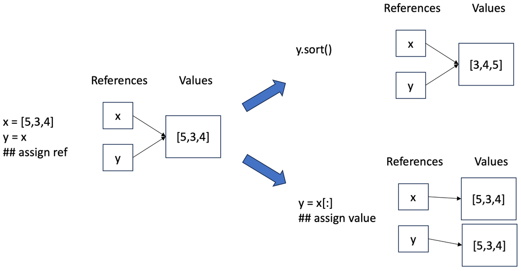

# list: sort

- sort

```python
x = ["aaa", "bb", "cccc"]
x.sort(key = len)
x
```

```
## ['bb', 'aaa', 'cccc']
```

```python
x = [5, 3, 4]
x.sort(reverse = True)
print(x)
```

```
## [5, 4, 3]
```

# dictionary: basic operator

- basic operator

```python
phonebook = {"Alice": 2341,
            "Beth": 4971,
            "Carl": 9401
}
phonebook
```

```
## {'Alice': 2341, 'Beth': 4971, 'Carl': 9401}
```

```python
len(phonebook)
```

```
## 3
```

```python
phonebook["Beth"]
```

```
## 4971
```

# dictionary: update and delete

- update and delete

```python
phonebook["Alice"] = 1358
phonebook
```

```
## {'Alice': 1358, 'Beth': 4971, 'Carl': 9401}
```

```python
adict = {"Alice": 9572}
phonebook.update(adict)
phonebook
```

```
## {'Alice': 9572, 'Beth': 4971, 'Carl': 9401}
```

```python
del phonebook["Carl"]
"Beth" in phonebook
```

```
## True
```

# dictionary: clear

- clear

```python
d = {}
d['name'] = "Amy"
d['age'] = 24
d
```

```
## {'name': 'Amy', 'age': 24}
```

```python
d.clear()
d
```

```
## {}
```

# why clear is useful

```python
x = {}
y = x
x['key'] = 'value'
y
```

```
## {'key': 'value'}
```

```python
x = {} ## now x points to a new value {}
y ## y points to the original value {'key': 'value'}
```

```
## {'key': 'value'}
```

```python
x = {}
y = x
x['key'] = 'value'
y
```

```
## {'key': 'value'}
```

```python
x.clear() ## clear the value x points to
y ## y still points to what x points to
```

```
## {}
```

# references and values (part 2)

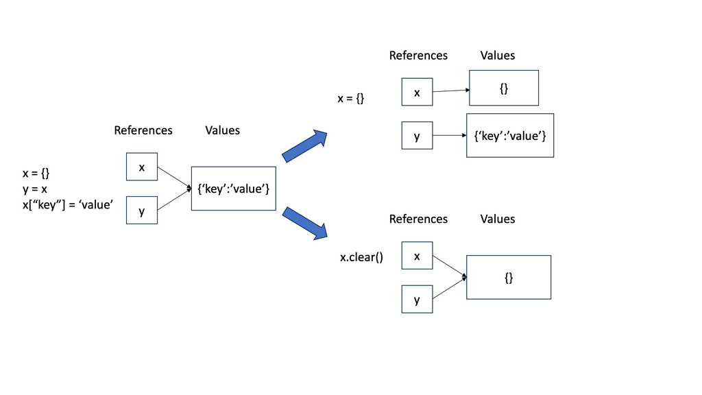

# copy

- shallow copy
  - only the reference address of the object is copied

```python
d = {}
d['username'] = "admin"
d['machines'] = ["foo", "bar"]
d
```

```
## {'username': 'admin', 'machines': ['foo', 'bar']}
```

```python
c = d.copy()
c['username'] = "Alex" ## c['username'] points to a new value
print(c)
```

```
## {'username': 'Alex', 'machines': ['foo', 'bar']}
```

```python
print(d)
```

```
## {'username': 'admin', 'machines': ['foo', 'bar']}
```

```python
c['machines'].remove("bar") ## references don't change, the underlying values are changed.
print(c)
```

```
## {'username': 'Alex', 'machines': ['foo']}
```

```python
print(d)
```

```
## {'username': 'admin', 'machines': ['foo']}
```

# references and values (shallow copy)

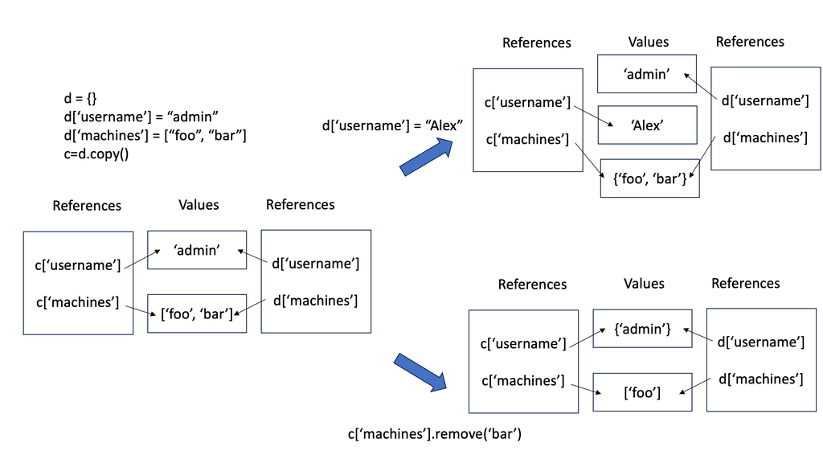

# copy

- deep copy:
  - will make a new copy of the values

```python
from copy import deepcopy

d = {}
d['username'] = "admin"
d['machines'] = ["foo", "bar"]
d
```

```
## {'username': 'admin', 'machines': ['foo', 'bar']}
```

```python
c = d.copy()
dc = deepcopy(d)
d['machines'].remove("bar")
print(c)
```

```
## {'username': 'admin', 'machines': ['foo']}
```

```python
print(dc)
```

```
## {'username': 'admin', 'machines': ['foo', 'bar']}
```

# references and values (deep copy)

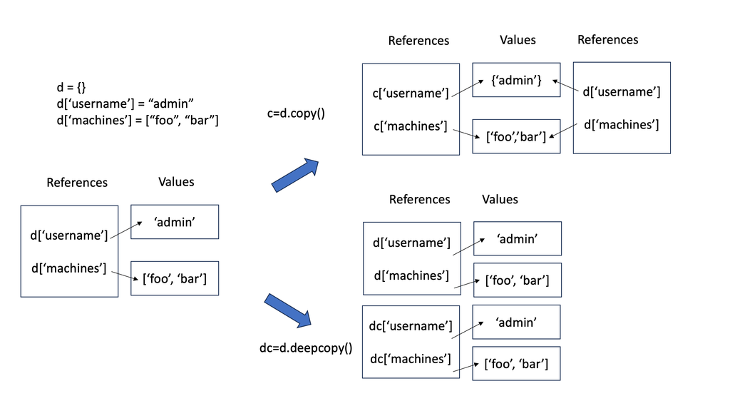

# dictionary initialization: fromkeys

- create keys for an empty dictionary.

```python
{}.fromkeys(["name", "age"])
```

```
## {'name': None, 'age': None}
```

- create keys for a dictionary

```python
dict.fromkeys(["name", "age"])
```

```
## {'name': None, 'age': None}
```

- set default values

```python
dict.fromkeys(["name", "age"], "unknown")
```

```
## {'name': 'unknown', 'age': 'unknown'}
```

# dictionary: get

- get method is more flexible
- get is the same as indexing by keys when the key exists

```python
d = {"name": "Amy", "age": 24}
d["name"]
```

```
## 'Amy'
```

```python
d.get("name")
```

```
## 'Amy'
```

- get will return None when the key doesn’t exist

```
d["XX"]
d.get("XX")
d.get("XX", "No exist") ## set your own return value for get
```

# dictionary: items

- items() return all items of the dictionary

```python
phonebook = {"Alice": 2341,
            "Beth": 4971,
            "Carl": 9401
}
phonebook
```

```
## {'Alice': 2341, 'Beth': 4971, 'Carl': 9401}
```

```python
phonebook.items() ## this is an iterable
```

```
## dict_items([('Alice', 2341), ('Beth', 4971), ('Carl', 9401)])
```

```python
list(phonebook.items())
```

```
## [('Alice', 2341), ('Beth', 4971), ('Carl', 9401)]
```

# dictionary: loops

- can be used for looping a dictionary

```python
it = phonebook.items()
for key, value in it:
    print(key +  "--> " + str(value))
```

```
## Alice--> 2341
## Beth--> 4971
## Carl--> 9401
```

- if you only want the value, not the keys

```python
it = phonebook.items()
for _, value in it:
    print(str(value))
```

```
## 2341
## 4971
## 9401
```

- use key to iterate a dictionary for a loop

```python
for key in phonebook:
    print(key +  "--> " + str(phonebook[key]))
```

```
## Alice--> 2341
## Beth--> 4971
## Carl--> 9401
```

- use values() method

```python
phonebook.values() ## this is an iterable
```

```
## dict_values([2341, 4971, 9401])
```

```python
list(phonebook.values())
```

```
## [2341, 4971, 9401]
```

```python
for i in phonebook.values():
    print(i)
```

```
## 2341
## 4971
## 9401
```

# dictionary: pop and popitem

- pop

```python
phonebook = {"Alice": 2341,
            "Beth": 4971,
            "Carl": 9401
}
phonebook.pop("Alice")
```

```
## 2341
```

```python
phonebook
```

```
## {'Beth': 4971, 'Carl': 9401}
```

- popitem(): pop up the last item

```python
phonebook = {"Alice": 2341,
            "Beth": 4971,
            "Carl": 9401
}
phonebook.popitem()
```

```
## ('Carl', 9401)
```

```python
phonebook
```

```
## {'Alice': 2341, 'Beth': 4971}
```

# tuple: review basics

```python
atuple = (0,1,2)
atuple += (3,4,5)
atuple
```

```
## (0, 1, 2, 3, 4, 5)
```

```python
btuple = (0, 1, 1, ['I', 'like',  'python'])
btuple[3][0] = 'You'
print(btuple)
```

```
## (0, 1, 1, ['You', 'like', 'python'])
```

```python
print(btuple.count(1))
```

```
## 2
```

```python
print(btuple.index(['You', "like", 'python']))
```

```
## 3
```

# Reference

- https://docs.python.org/3/index.html
- https://github.com/Apress/beginning-python-3ed